# Introduction to R

A Practically Focused Guide

Andy Grogan-Kaylor

May 04, 2018

# 1 Background

> This work is licensed under a [Creative Commons Attribution-ShareAlike 4.0 International License](http://creativecommons.org/licenses/by-sa/4.0/)

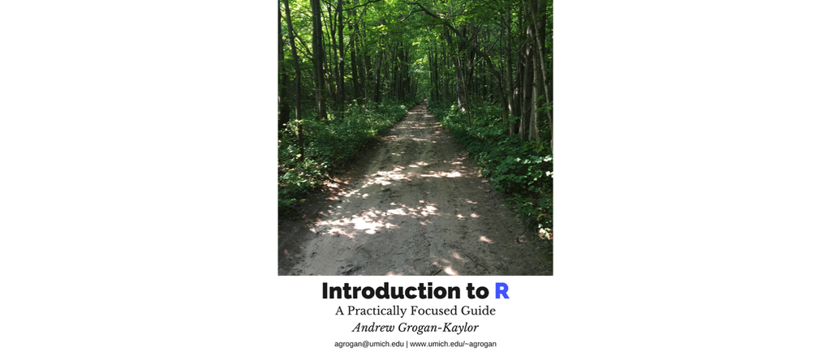

Cover Image

[R](https://www.r-project.org/) is open source, and therefore free, statistical software with particular strengths in obtaining, analyzing and visualizing data. R has an admittedly steep learning curve. However, I believe that it is possible to teach R in an accessible way, and that a little bit of R can take you a long way.

This document is a brief introduction to R[^1], in order to create a kind of “cheat sheet” that can be presented in a few pages. Commands that you actually type into R are represented in `courier font`. `mydata` is the name of your data set. `x` and `y` and `z` refer to variables in your data. More documentation on any command is usually available via `help(command)` or `??command`. The R interface makes it extremely easy to do rapid interactive data analysis. Hit **“Up-Arrow”** to recall the most recent command, which you can then quickly edit and resubmit. Remember also that one often submits a command or set of commands from a script window. The general idea of many R commands is:

```r
command(data = mydata, ...variables..., options)
```

or

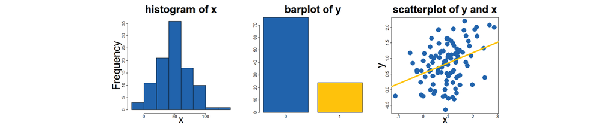

Graphical Possibilities in Base R

```r
command(mydata$xvar, options)
```

> The $ sign is a kind of “connector”. `mydata$x` means: “The variable `x` in the dataset called `mydata`”.

Sometimes, it is not necessary to use any options since some authors of R have done a good job of thinking about the defaults. R can make use of long pathnames[^2] to files like:

```r
C:/Users/user1/Desktop/mydata.sav
```

# 2 Base R and Libraries

This guide is mainly written for social researchers who are mostly interested in using R to analyze and visualize data.

Most of this guide makes use of what is most often called **Base R**, the R that you get when you install the R software, and RStudio, on your computer.

For many social researchers, the data structure of primary interest is the *data frame*, and thus that is my focus here. In the interests of parsimony I do not go into a great deal of detail on R’s other data structures.

A great deal can be accomplished with **Base R**. However, as you grow in your use of R, you will likely frequently need to make use of libraries, which are invoked by the `library(...)` command. Before using a library you need to install it. Below is an example of installing the *ggplot2* advanced graphics library.

> You would need to install the library only once. Installation can also be accomplished from the “Packages” tab in RStudio.

```r
install.packages("ggplot2")
```

Then start the library when you are using R by typing…

```r
library(ggplot2)
```

I should mention here the new additions to the R language of the new libraries which make up the [**tidyverse**](https://www.tidyverse.org/). Learning the [**tidyverse**](https://www.tidyverse.org/) requires an additional investment in learning, however the **tidyverse** makes many improvements to the R language and functionality.

# 3 Working Directory

It is often helpful to simply set your working directory to a particular location and by default, files will be accessed from, and saved to, that directory e.g.:

```r
getwd() # "get", or find out, your working directory

setwd("C:/Users/user1/Desktop/") # set your working directory
```

# 4 Writing R Code or Script

R is a command or syntax based program, and many advanced functions are only available via syntax.

> R Commands are stored in a *script* or *code* file that usually ends in .R, e.g. `myRscript.R`. The command file is distinct from your actual data, stored in an .RData file, e.g. `mydata.RData`.

Base R can sometimes be cryptic.

> However, a little bit of Base R can go a long way, and you can get a great learning return for a little bit of investment in learning Base R.

# 5 Graphical User Interface

A good **Graphical User Interface** (GUI) can make some of the base functionality of R available without the use of syntax. [**RCommander**](http://socserv.mcmaster.ca/jfox/Misc/Rcmdr/) is the best GUI, and can be installed from the command line by typing:

```r
install.packages("Rcmdr", dependencies=TRUE)
```

**RCommander** can make some tasks easier, but the syntax that it produces can sometimes be non-intuitive. Often it is easiest (and more in the interests of replicable research) just to learn how to write the `R code` that accomplishes a particular task. Further, your learning may go quicker if you bypass **RCommander** altogether and simply learn how to write R code.

[figure not shown]

screenshot of RCommander

[**RStudio**](http://www.rstudio.com/) is an **Integrated Development Environment (IDE)** that can be run simultaneously with **RCommander** and provides an easier working enivronment for R Software. If all the software is installed, Start **RStudio** to start R, then type `library(Rcmdr)` to start **RCommander**.

[figure not shown]

screenshot of RStudio

# 6 Get Your Data

## 6.1 R format (*.RData)

R most easily makes use of data in R format. Data can be loaded with the `load()` command.

```r
load("pathto/myRfile.RData")
```

> Note–as we discuss in a little more detail below–that a single data file can contain multiple data frames.

For example, a data file called **projectdata.RData** could contain:

- A data frame on *clients*, called **clients**.
- A data frame on *providers*, called **providers**.
- A data frame on *facilities*, called **facilites**.

> The name of the *RData file* can be **very different** from the name of the *data frames* that it contains.

## 6.2 Comma Separated Values (*.csv)

R can also read *comma separated values (csv)*.

```r
library(readr) # to read csv

mydata <- read_csv("myCSVfile.csv")
```

## 6.3 Statistical Packages and Excel

R can easily import well-formatted data from other packages} like SPSS, Stata, or Excel[^3].

## 6.4 `foreign`

```r
library(foreign) # library for importing from stats software

mydata <- read.spss("mySPSSfile.sav") # SPSS

mydata <- read.dta("myStatafile.dta") # Stata
```

## 6.5 `readxl`

```r
library(readxl) # library for importing Excel files

mydata <- read_excel("mySpreadsheet.xls") # Excel
```

## 6.6 `haven`

`haven` is a new library for reading in data from statistical packages that may work better.

```r
library(haven) # new library for importing from stats software

dataset <- read_sav("mySPSSfile.sav") # SPSS

dataset <- read_stata("myStatafile.dta") # Stata
```

# 7 Save Your Data in R Format

Once you have your data in R, it will likely make sense to save it in `*.RData` format for future use.

```r
save(mydata, file = "mydata.RData")
```

> Note–as we alluded to earlier–that multiple data frames can be saved into a single data file.[^4]

```r
save(clients, # a first data frame, about clients
     providers, # a second data frame, about providers
     facilities, # a third data frame, about facilities
     file = "projectdata.RData")
```

# 8 Save and Document Your Work

Use the Script Editor to save R commands that you want to use again, or to modify for the next project, as well as to create an “audit trail” of your work so that your workflow is documented and replicable. R commands are saved in a *.R* file, e.g. **myscript.R**.

# 9 Process Your Data

## 9.1 Data Subsets

Working with a *subset* of your data (i.e. fewer variables rather than many many variables) is often helpful. The subset function can be especially helpful.

```r
mydata_subset <- subset(mydata, # name of data
                        age > 18, # condition(s)
                        select = c(id, sex, income)) # variables
```

You can then run functions like `summary()` on a *subset* of your data.

```r
summary(mydata_subset)
```

You can also save this subset for future use.

```r
save(mydata_subset, file = "mydata_subset.RData")
```

## 9.2 Numeric and Factor Variables

R recognizes two basic kinds of variables: *continuous variables* (which R calls *“numeric” variables*) which are often scales like income, mental health, or neighborhood quality; and *categorical variables* (which R calls *“factor variables”*) like race, gender or religion.

R seems to make a stronger distinction between these two types of variables than some other statistical software.[^5] It can thus sometimes be useful to change variables from one type to another:

```r
mydata$x <- as.numeric(mydata$y)

mydata$x <- as.factor(mydata$y) # shorter syntax

# longer, more complete syntax

mydata$w <- factor(mydata$z, # original numeric variable
                   levels = c(0, 1, 2), # levels of numeric variable
                   labels = c("Group A", # labels
                              "Group B",
                              "Group C"),
                   ordered = TRUE) # often useful to order the levels
```

## 9.3 Missing Values

Data with missing values, often represented as negative numbers (e.g. -99, -9, -8) needs to be recoded so that the missing values are represented as a missing value character (“NA”) that R knows to exclude from calculations.

```r
mydata$x[mydata$x == -9] <-NA # Example 1

mydata$x[mydata$x == -8] <-NA # Example 2
```

## 9.4 Renaming Variables

It is often convenient to rename your data so that the variables have more intuitively understandable names e.g.

```r
mydata$age <- mydata$var123

mydata$gender <- mydata$var456
```

## 9.5 Sorting Data

It is sometimes useful to sort your data. `sort(mydata$x)` will sort mydata by the values of `x`.

## 9.6 Creating New Variables

You can easily create new variables in R. For example, a change score between a measure collected at two time-points, like a pre-test, and a post-test, would be:

```r
mydata$change_x <- mydata$xTime2 - mydata$xTime1
```

## 9.7 Scales or Measures

Similarly, you can sum the items of a scale into a scale as follows:

```r
mydata$myscale <- mydata$x1 + mydata$x2 + mydata$x3
```

You can test the alpha reliability of this scale with the following syntax:

```r
myscale_data <- subset(mydata, select = c(x1, x2, x3))
```

The syntax above create a dataframe of only the scale items.

Then,

```r
library(psych)

alpha(myscale_data)
```

# 10 Descriptive Statistics

`summary(mydata$x)` gives you basic descriptive statistics for a variable, such as the mean (average). Especially useful for continuous variables. Use `summary(mydata)` to summarize every variable in your data. `describe(mydata$x)` from `library(psych)` will often give you a nicer summary of your variables that is closer to what you want for an academic paper or agency report.

`table(mydata$x)` gives you a frequency distribution for your variable. Especially useful for *factor variables*. `prop.table(table(mydata$x))` will give you a table of proportions. Calling up `library(descr)` and then using `freq(mydata$x)` will give you a more nicely formatted frequency distribution.

# 11 Bivariate Statistics

Tabulating two categorical variables (*factor variables*) together gives you a cross-tabulation of those variables, e.g:

```r
table(mydata$x, mydata$y) # simple table of counts

prop.table(table(mydata$x, mydata$y)) # table of cell proportions

prop.table(table(mydata$x, mydata$y)
           margin = 1) # row margins: row proportions

prop.table(table(mydata$x, mydata$y)
           margin = 2) # column margins: column proportions
```

then

```r
chisq.test(table(mydata$x, mydata$y))
```

will give you a chi-square test of the relationship of `x` and `y`.

```r
cor(mydata[,c("x","y")], use="complete.obs")
```

will give you the correlation of continuous variables `x` and `y`[^6].

```r
cor.test(mydata$x, mydata$y,
         alternative="two.sided",
         method="pearson")
```

will test the statistical significance of this correlation.

```r
numSummary(mydata$x, groups=mydata$z)
```

gives you a summary of continuous variable `x` by *factor variable* `z`.

```r
t.test(mydata$x~mydata$z)
```

runs a t-test of continuous variable `x` over *factor variable* `z`.

```r
aov(x ~ z, data=mydata)
```

runs the corresponding ANOVA of continuous variable `x` across *factor variable* `z`.

# 12 Multivariate Statistics

```r
mymodel <- lm(y ~ x + z, data=mydata)
```

runs a regression (linear model) of `y` on `x` and `z`, type

```r
summary(mymodel)
```

to display the results

# 13 Graphing

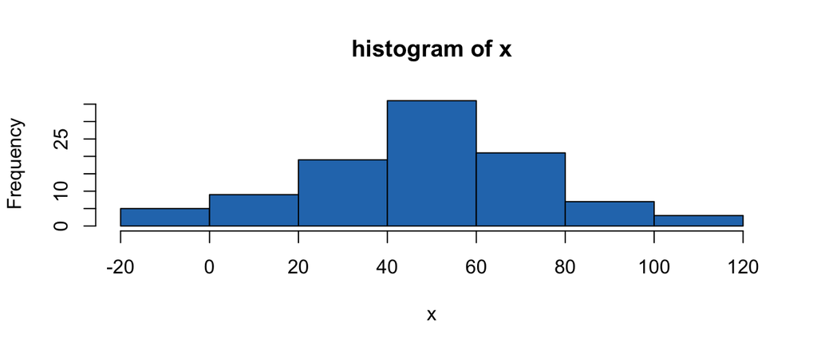

histogram of x

```r
hist(mydata$x)
```

will give you a nice display of one continuous variable.

```r
hist(mydata$x, main="...", xlab="...")
```

gives a nicer looking graph.

```r
barplot(table(mydata$x))
```

gives similar results when x is a *factor variable*.

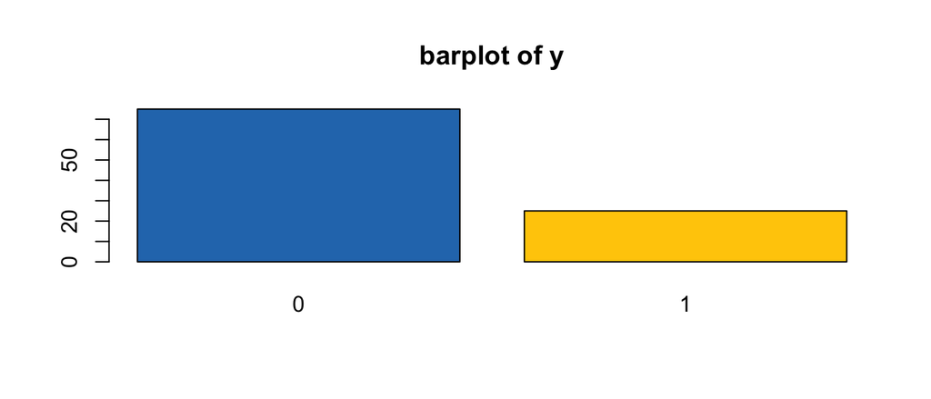

barplot of y

```r
plot(mydata$y, mydata$x)
```

gives you a twoway scatterplot of your data

A more nicely labelled graph can be obtained with:

```r
plot(y, x,
     main= "...",
     xlab= "...",
     ylab= "...")
```

`abline(lm(mydata$y~mydata$x))` will add a linear fit line to a scatterplot that you have already constructed.

`abline(lm(mydata$y~mydata$x), col="gold", lwd=5)` will be a nicer looking fit line.

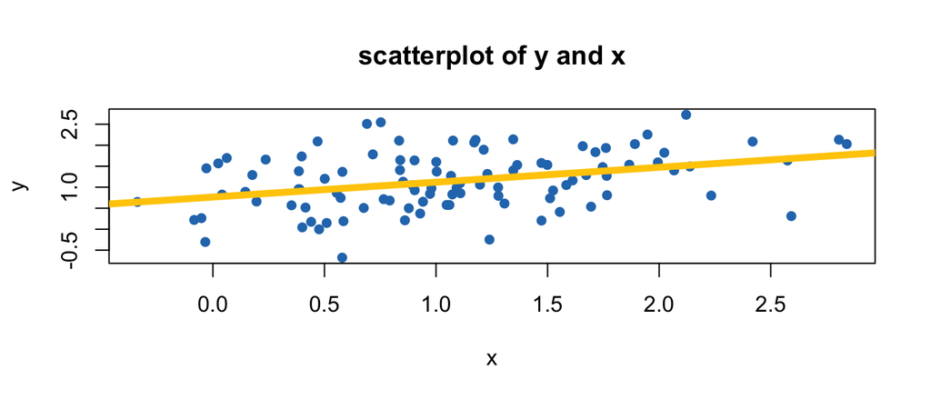

scatterplot of y against x

# 14 Comments, Questions and Corrections

Comments, questions and corrections most welcome and may be sent to: Andrew Grogan-Kaylor @ http://www.umich.edu/~agrogan & @ agrogan@umich.edu.

Last updated: `May 04 2018` at `09:05`

[^1]: This document is inspired by my longstanding “Two Page Stata” document: [(PDF)](http://www-personal.umich.edu/~agrogan/stata/TwoPageStata.pdf) [(HTML)](http://www-personal.umich.edu/~agrogan/stata/TwoPageStata.html).
[^2]: Note that R uses forward slashes “/” instead of backslashes “”.
[^3]: These instructions assume you have `setwd()` appropriately, or alternatively are specifying a full pathname and filename.
[^4]: Some would call this a *feature* of R, while others would simply say that this is another *confusing aspect* of R.
[^5]: In many cases, this is very helpful in that R recognizes that the type of variable calls for a certain kind of statistic or graph, or vice versa. In other cases, this may be the source of an *error message*.
[^6]: Here is an example where R turns a simple issue into a difficult one, and the syntax is frankly less than elegant, and not intuitive. I don’t have this syntax memorized. I use `library(Rcmdr)` if I need to test, or create a script for, a correlation.